# Mouse Forecast

Seasonal house mouse forecast for Australian grain-growing regions

## Outlook for Spring 2026

Predictions for September to November 2026

- Western Australia:
  - Northern (Geraldton) region: Mouse numbers have reduced from previous seasons, but recent surveys confirm numbers remain relatively high.
  - Sandplain (Esperance) region: Mouse numbers are expected to be moderate across more than half of the region, likely due to exceptional winter crop growth.
  - Central and Eastern regions: Mouse numbers mostly low.
- South Australia:
  - Surveys have found mostly low numbers except on southern Yorke Peninsula, which detected moderate mouse activity.
  - Despite overall low survey results, above-average winter crop growth and a recent swing from long-term dry to wet conditions (which often comes before outbreaks) point to a risk of higher numbers in coming seasons.
  - With no recent surveys in the Far West, Upper Eyre Peninsula or around Jamestown, the model forecasts high numbers there from conditions alone, but with considerable uncertainty (shown with pale red in Figure 1) - this estimate should be taken with a large grain of salt.
- Victoria:
  - Mallee: Mouse numbers are potentially moderate in parts of the Mallee north of Birchip, towards Swan Hill. This is likely due to good winter crop growth, and a recent swing from long-term dry to wet conditions increases the risk of numbers rising further in coming seasons.
  - Elsewhere: Mouse numbers are expected to be low.
- New South Wales:
  - Mouse numbers are mostly low, except for possible moderate numbers in parts of the Liverpool Plains (near Gunnedah) and the eastern Riverina (near Temora and Wagga Wagga).
- Southern Queensland:
  - Mouse numbers are expected to be mostly low but with patches of moderate activity throughout. Estimated patchy moderate numbers are supported by reports of mouse damage and control action occuring in some places.

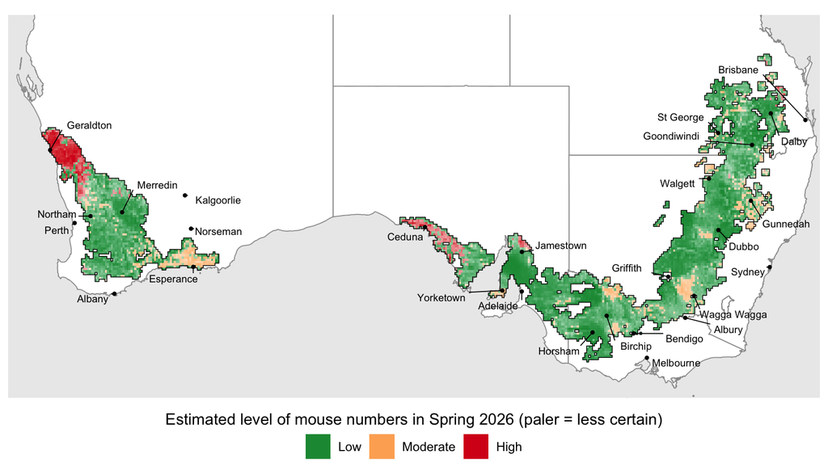

Figure 1: Most likely level of mouse numbers in Spring 2026 predicted across key grain-growing areas (shown at a 10 × 10 km spatial resolution). “Low” numbers reflect typical yearly fluctuations in mouse numbers, with “moderate” numbers rising above normal levels where crop damage is possible (potentially in a build-up phase), and “high” approaching or at concerning numbers where crop damage is likely. Paler shades show where the forecast is less certain of that level. The forecast is based on past mouse surveys, environmental conditions in the previous season, and this season’s surveys at nearby paddocks.

## Management recommendations

Disclaimer: forecasts and recommendations are prepared by CSIRO researchers from the data and resources available, and should only be used as a guide when making business decisions.

- Monitor mouse activity in crops before harvest. This is particularly important in locations shaded red in Figure 2 below, as these areas have a greater than 50% chance of moderate or high mouse numbers.
- Monitor using chew cards or a walk-through checking for crop damage ([GRDC: know your mouse numbers](https://grdc.com.au/resources-and-publications/resources/mouse-management/monitor-manage/know-your-mouse-numbers)). Active burrow counts are generally less reliable at this time of year due to poor visibility.
- Aim for a clean harvest with minimal grain loss to reduce food for mice in stubble, particularly where a wet finish delays harvest. Keep monitoring after harvest, as mouse numbers then set the risk for next season’s sowing.
- If you find mice or damage after harvest, consider applying zinc phosphide bait ([GRDC: mouse baiting](https://grdc.com.au/resources-and-publications/resources/mouse-management/monitor-manage/mouse-baiting)) before sowing. Most winter crops are now close to maturity, and bait becomes less attractive once grain develops in the head, so in-crop baiting is only worthwhile in crops still well short of maturity (be aware of the 14-day withholding period specified on the label).
- Growers sowing summer crops should check paddocks and neighbouring stubble before planting, and consider baiting at or immediately after sowing if mice are present.
- ZnP25 is registered nationally. Use it according to the label and report any adverse effects via the [APVMA adverse experience reporting program](https://www.apvma.gov.au/regulation/adverse-experience-reporting-program). An emergency permit currently allows use of the higher-dose ZnP50 bait. Check where it applies, its conditions and its expiry on the [GRDC mouse management page](https://grdc.com.au/resources-and-publications/resources/mouse-management).

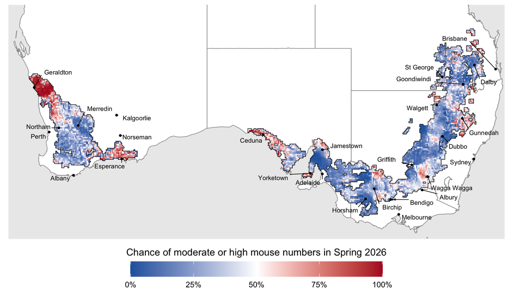

Figure 2: Chance of mouse numbers being moderate or high in Spring 2026. Red shows where mouse numbers are more likely to be moderate or high than low. Blue shows where mouse numbers are more likely to be low than moderate or high. White areas within the grain-growing regions (outlined in black) show an equal chance of being low or moderate or high (the same chance as a coin toss). Moderate or high mouse numbers are a level where growers should monitor mouse numbers in paddocks and be prepared to take management action.

## Report mouse activity

Take 60 seconds to report mouse activity on your farm on [MouseAlert](https://feralscan.org.au/mousealert).

We are primarily seeking observations from within paddocks (not houses or farm sheds), and particularly encourage reporting of low activity – not just observations of high mouse activity. This helps both inform and validate our forecasts.

## About

Mouse forecasts are enabled through a [Grains Research and Development Corporation and CSIRO investment into the 2025–29 Mouse Monitoring and Surveillance project](https://groundcover.grdc.com.au/grdc/announcements/investments-target-new-normal-of-mouse-activity) via the [Rodent Management team](https://research.csiro.au/rm/). Forecasts will be updated seasonally or as new data becomes available.

We are actively testing and improving the statistical forecast model, and working on its presentation. This work is coordinated with the National Mouse Group, a grower-led network of farmers, industry representatives, state government, GRDC and CSIRO. The group meets three times a year to share local reports of the current mouse situation, review management recommendations and determine research priorities.

### Monitoring data

Mouse population surveys are conducted 3–4 times a year at each of the ~170 long-term monitoring sites. Mice are surveyed through active burrow searches and chew cards. To calibrate this data against more robust population density measurements, we also conduct live-trapping at 4 sites (Adelaide Plains SA, Northern Mallee VIC, Central West NSW and Moree NSW).

Mouse monitoring data is collected by CSIRO, NSW Local Land Services, NSW Department of Primary Industries and Regional Development, Central West Farming Services, Birchip Cropping Group, and Farmanco. We also thank NSW DPIRD, who generously provide additional live-trapping survey data. Further live-trapping data is occasionally supplied through the [GRDC / CSIRO Mouse Ecology 2024–2029 project](https://research.csiro.au/rm/research-projects/mouse-ecology-2024-2029/).

We also receive reports from farmers, agronomists and other community members directly. These reports are valuable, as we cannot feasibly survey every paddock across the grain-growing region.

### How the forecast works

- **A statistical model.** Built on more than 40 years of mouse surveys (live-trapping, active burrow counts and chew cards), it estimates whether mouse numbers in each area are most likely low, moderate or high this season.
- **Three abundance levels.** Numbers move from low to moderate after conditions turn good, and from moderate to high most often after a sharp dry-to-wet swing. Both fall back to low when good conditions end.
- **What drives predictions.** Recent mouse survey data and environmental conditions: satellite crop growth, soil moisture, rainfall swings, temperature, soil type.
- **How far ahead.** One season, as it uses observed conditions, not weather forecasts.
- **How reliable.** Tested against plague years recorded before 2013 (records it was not trained on), it gives good warning in New South Wales, South Australia and Victoria and little in Queensland. It can’t yet be tested in Western Australia, which lacks reliable plague records for that period.
- **How to interpret.** The forecast shows regional risk, not individual paddocks, and will sometimes miss an outbreak or give a false alarm, so use it as a prompt to check your own paddocks.

### Contact

Questions about the forecast? Get in touch with Dr Matthew Rees at matt.rees@csiro.au.

For media enquiries, contact Research Officer Steve Henry (steve.henry@csiro.au) or the [CSIRO media office](https://www.csiro.au/en/news/Media-Centre).

We value your feedback.

## 📬 Stay updated

Receive seasonal mouse forecasts to your inbox